# Prueba 1 - Análisis de Sentimientos de Twitter-Copy1

## Revisión de Hashtags por polaridad del mensaje

```python
HT_positive = funcs.hashtag_extract(df['content'][df['polarity'] == 0])
HT_negative = funcs.hashtag_extract(df['content'][df['polarity'] == 1])

HT_positive = sum(HT_positive,[])
HT_negative = sum(HT_negative,[])
```

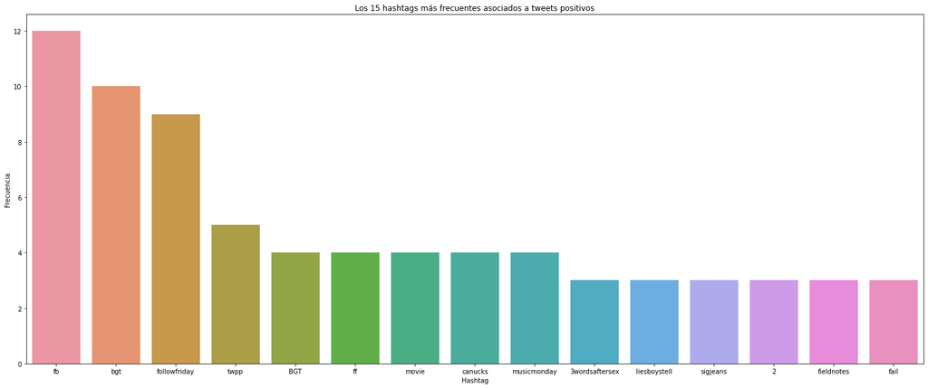

```python
a = nltk.FreqDist(HT_positive)
d = pd.DataFrame({'Hashtag': list(a.keys()),
                  'Count': list(a.values())})

d = d.nlargest(columns="Count", n = 15)
plt.figure(figsize=(25,10))
ax = sns.barplot(data=d, x= "Hashtag", y = "Count")
ax.set(ylabel = 'Frecuencia')
plt.title('Los 15 hashtags más frecuentes asociados a tweets positivos')
plt.show()
```

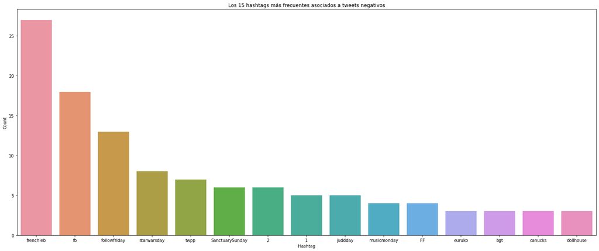

```python
b = nltk.FreqDist(HT_negative)
e = pd.DataFrame({'Hashtag': list(b.keys()), 'Count': list(b.values())})

# selecting top 20 most frequent hashtags
e = e.nlargest(columns="Count", n = 15)
plt.figure(figsize=(25,10))
ax = sns.barplot(data=e, x= "Hashtag", y = "Count")
plt.title('Los 15 hashtags más frecuentes asociados a tweets negativos')
plt.show();
```

Viendo las distribuciones de los Hashtags asociados a las 2 polaridades se asejeman entre ellos, son diversos en cuanto a los tópicos sobre los que se están comentando en la red

```python
tweets_clean = df['tweets'].tolist()

wordnet = WordNetLemmatizer()

tweets_lem = []

for word in tweets_clean:
    lem_word = wordnet.lemmatize(word)
    tweets_lem.append(lem_word)
```

```python
df_lem = pd.DataFrame(tweets_lem, columns =['tweets_lem'])
df = pd.concat([df,df_lem], axis = 1)

df.head()
```

|  | content | sentiment | tweets | len_content | sentiment_dum | polarity | tweets_lem |
| --- | --- | --- | --- | --- | --- | --- | --- |
| 0 | Happy Mama's day to all mothers | love | Happy Mama's day to all mothers | 31 | positivo | 1 | Happy Mama's day to all mothers |
| 1 | @LysdelTellez I am lost. Please help me find a... | worry | I am lost. Please help me find a good home. | 57 | negativo | 0 | I am lost. Please help me find a good home. |
| 2 | @BoomKatt yes yes I AM, networking whore to th... | happiness | yes yes I AM, networking whore to the fullest... | 93 | positivo | 1 | yes yes I AM, networking whore to the fullest... |
| 3 | you@snapplynn Wish that would have been your t... | neutral | you Wish that would have been your tweet after... | 73 | positivo | 1 | you Wish that would have been your tweet after... |
| 4 | now i am doing the MicroEconomics project iha... | worry | now i am doing the MicroEconomics project iha... | 133 | negativo | 0 | now i am doing the MicroEconomics project iha... |

### Tokenización de tweets

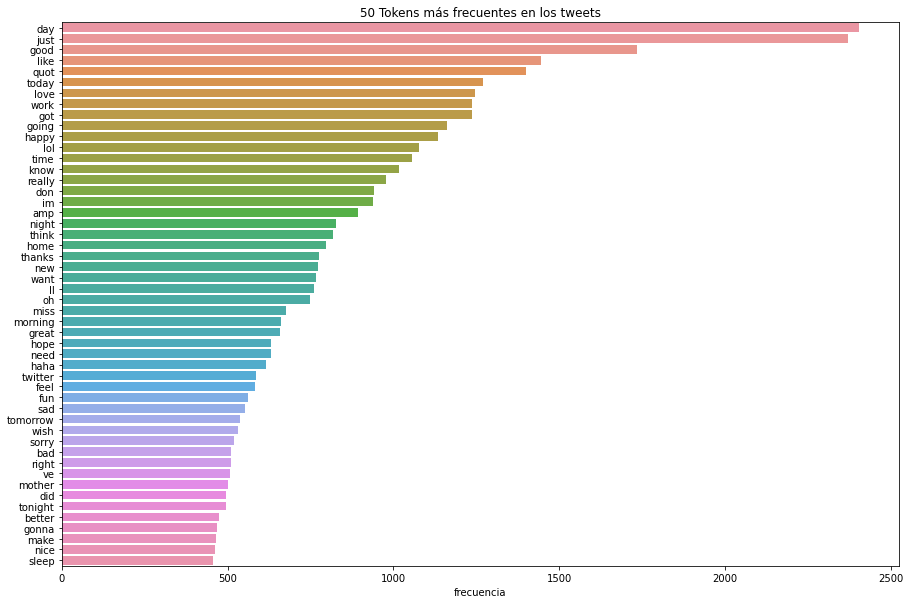

```python
df_words = funcs.get_words(df,'tweets_lem')

plt.figure(figsize=(15, 10))
wordplot = sns.barplot(x='frecuencia',
                  y=df_words.index,
                  data=df_words
                          )
wordplot.set_title('50 Tokens más frecuentes en los tweets');
```

### División muestra de entrenamiento y validación

```python
y = df['polarity']
X = df['tweets_lem']

X_train,X_test,y_train,y_test = train_test_split(X,y, test_size = 0.33, random_state = 18268)
```

## Evaluación de modelos sin hiperparámetros

### Pipeline

```python
random_seed = 123445

modelos = ['Logistic Regression','Decision Tree','XGBoost','Random Forest','Adaboost']

log_model = Pipeline([('counter_vectorizer', CountVectorizer(stop_words = 'english', max_df = 0.1, max_features = 15000)),
                     ('log_model', LogisticRegression(random_state=random_seed))])

tree_model = Pipeline([('counter_vectorizer', CountVectorizer(stop_words = 'english', max_df = 0.1, max_features = 15000)),
                     ('tree_model', DecisionTreeClassifier(random_state=random_seed))])

xgboost_model = Pipeline([('counter_vectorizer', CountVectorizer(stop_words = 'english', max_df = 0.1, max_features = 15000)),
                     ('gboost_model', XGBClassifier(random_state = random_seed))])

rfc_model = Pipeline([('counter_vectorizer', CountVectorizer(stop_words = 'english', max_df = 0.1, max_features = 15000)),
                     ('rfc_model', RandomForestClassifier(random_state = random_seed))])

adaboost_model = Pipeline([('counter_vectorizer', CountVectorizer(stop_words = 'english', max_df = 0.1, max_features = 15000)),
                    ('adaboost_model', AdaBoostClassifier(random_state = random_seed))])
```

### Comparación modelos Vainilla

```python
%%time
funcs.models_evaluation(X_train, y_train, 5,log_model,tree_model,xgboost_model,rfc_model,adaboost_model,modelos)
```

```
CPU times: user 3min 14s, sys: 1.46 s, total: 3min 16s
Wall time: 2min 17s
```

|  | Logistic Regression | Decision Tree | XGBoost | Random Forest | Adaboost | Best Score |
| --- | --- | --- | --- | --- | --- | --- |
| Accuracy | 0.670846 | 0.616318 | 0.671095 | 0.656219 | 0.646418 | XGBoost |
| Precision | 0.673036 | 0.614784 | 0.712498 | 0.653196 | 0.735971 | Adaboost |
| Recall | 0.646928 | 0.594879 | 0.558458 | 0.646022 | 0.441945 | Logistic Regression |
| F1 Score | 0.659717 | 0.604575 | 0.626115 | 0.649545 | 0.552062 | Logistic Regression |

1. Al momento de mirar las principales métricas ( F1-Score, Recall, Precision) y sin sin aplicar hiperparámetros, nos encontramos que son muy dispares en cuanto a cúal es el mejor entre ellos.
1. Considerando solo Recall y F1-Score se tiene que los mejores modelos son el Random Forest y Regresión Logística.

```python
models = {'Logistic Regression': log_model.fit(X_train,y_train)
          ,'Decision Tree': tree_model.fit(X_train,y_train)
          ,'XGBoost': xgboost_model.fit(X_train,y_train),'Random Forest': rfc_model.fit(X_train,y_train)
          ,'Adaboost': adaboost_model.fit(X_train,y_train) }
```

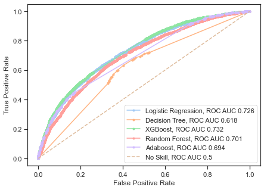

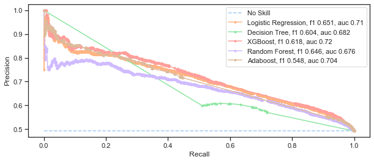

```python
funcs.plot_roc_curves(models,X_test,y_test)
funcs.plot_precision_recall_curves(models, X_test, y_test)
```

1. Revisando la curva ROC se tiene que los mejores modelos serían la Regresión Logística y XGBoost.
1. El modelo de Árbol de Decisión no logra un comportamiento estable con una data desbalanceada y sin definir ciertas reglas de clasificación del mismo.